# Informe Final del Estudio sobre Adicción a las Redes Sociales

Daniela Fishwick

07/03/2025

## **Introducción**

El presente informe tiene como objetivo analizar los resultados de un estudio sobre la adicción a las redes sociales, realizado entre estudiantes universitarios. El estudio se llevó a cabo mediante una encuesta que recopiló datos sobre el uso de redes sociales, su impacto en la vida académica y laboral, y otros factores relacionados con la salud mental y el bienestar. El dataset contiene información de 641 encuestados, con variables que abarcan desde el tiempo promedio de uso diario de redes sociales hasta el estado de relación de los participantes. Este informe se centrará en el análisis descriptivo y la exploración de las variables recabadas en el estudio. Además, se realizarán pruebas de normalidad y visualizaciones para cada variable, con el fin de determinar si se ajustan a distribuciones conocidas y si son adecuadas para análisis estadísticos posteriores. Finalmente, se presentarán conclusiones y recomendaciones basadas en los hallazgos del estudio.

## **Objetivos del Estudio**

El objetivo principal de este estudio es evaluar el impacto del uso de redes sociales en la vida académica y laboral de los estudiantes universitarios, así como identificar patrones de uso y posibles consecuencias negativas asociadas.

Los objetivos específicos incluyen:

1. Determinar la cantidad promedio de horas que los estudiantes pasan en redes sociales diariamente.
2. Evaluar si el uso de redes sociales afecta el rendimiento académico y laboral.
3. Analizar la relación entre el uso de redes sociales y la salud mental de los estudiantes.
4. Identificar las plataformas de redes sociales más utilizadas por los estudiantes.
5. Explorar la relación entre el estado de relación de los estudiantes y su uso de redes sociales.

## **Variables**

El dataset obtenido del estudio contiene las siguientes trece variables:

| Variable | Tipo | Descripción |
| --- | --- | --- |
| **Student_ID** | Integer | Identificador único del encuestado |
| **Age** | Integer | Edad en años |
| **Gender** | Categórico | M, F, Otro |
| **Academic_Level** | Categórico | Educación media / Pregrado / Postgrado |
| **Avg_Daily_Usage_Hours** | Float | Promedio de horas por día de uso en redes sociales |
| **Affects_Performance** | Boolean | Impacto en lo académico/laboral (Sí/No) |
| **Sleep_Hours_Per_Night** | Float | Promedio de horas de sueño por noche |
| **Mental_Health_Score** | Integer | Número de ocasiones en la última semana, con estado de ánimo afectado negativamente por las redes sociales |
| **Conflicts_Over_Social_Media** | Integer | Número de conflictos en el último mes, con relaciones interpersonales debido a las redes sociales |
| **Avg_Time_Between_Usage_Min** | Float | Tiempo promedio en minutos entre usos de redes sociales |
| **Most_Used_Platform** | Categórico | Instagram, Facebook, TikTok, WhatsApp, Otra. |
| **How_Many_Platform** | Integer | Número de plataformas utilizadas |
| **Relationship_Status** | Boolean | Relación de pareja (Sí/No) |

## **Análisis de Datos**

Se realizarán los análisis a cada una de las variables mostradas anteriormente. El tipo de análisis que se realizará a cada una de ellas fue definido en el informe previo de Diseño de la Encuesta.

## **1. Análisis de la variable “Edad”**

El tipo de variable “Edad” es cuantitativa continua, ya que representa un valor numérico que puede tomar cualquier valor dentro de un rango. En este caso, la variable “Edad” se analizará utilizando la distribución normal, dado que se espera que la edad de los encuestados siga una distribución aproximadamente normal en una población grande.

### **Análisis descriptivo**

```
## --- Estadísticas Descriptivas para 'Edad' ---
```

```
##    Min. 1st Qu.  Median    Mean 3rd Qu.    Max.
##    18.0    20.0    21.0    20.7    22.0    24.0
```

```
## Edad Promedio (mean): 20.6817
```

```
## Desviación Estándar (sd): 1.3948
```

```
## Mediana: 21
```

**Interpretación:**

Los resultados indican que la **edad promedio** de los encuestados es de aproximadamente 20.6817 años, con una desviación estándar de 1.3948 años. El 50% de los encuestados tiene 21 años o menos (mediana), y el rango de edades en la muestra es de 18 a 24 años. La concentración de datos alrededor de la media y la baja desviación estándar sugieren una población estudiantil con edades relativamente uniformes.

#### **Visualización: Histograma de Edad**

Un histograma nos ayuda a visualizar la distribución de la variable `Edad`.

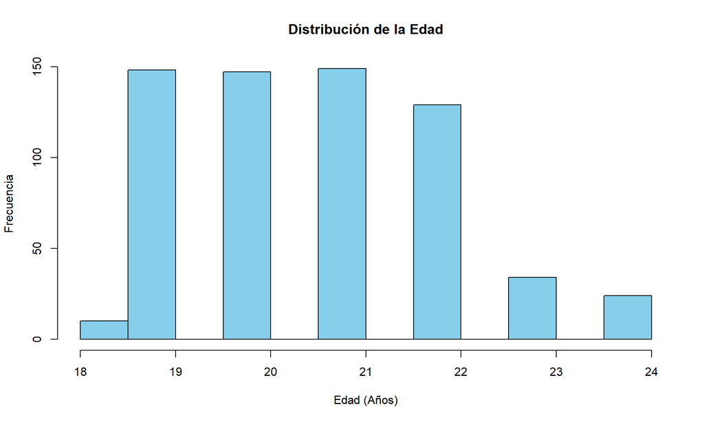

#### **Visualización: Diagrama de Caja (Box Plot) de Edad**

Un diagrama de caja es útil para identificar la dispersión de los datos y posibles valores atípicos (outliers).

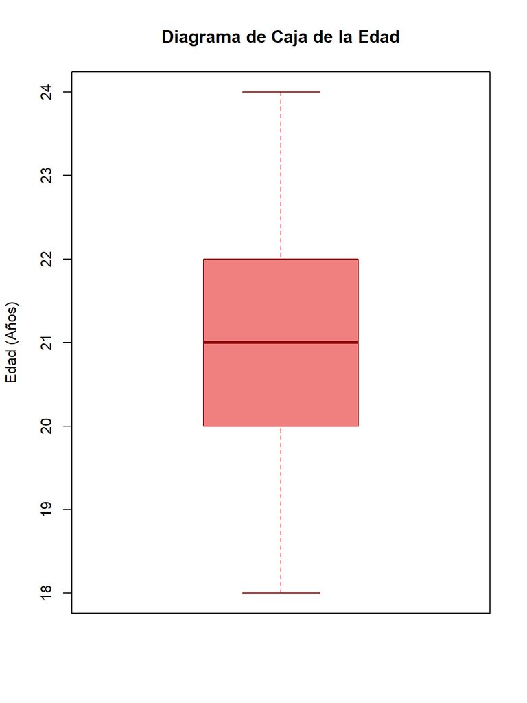

**Interpretación de las Visualizaciones:**

El **histograma** muestra que la mayoría de los encuestados se concentran en el rango de 18 a 22 años, lo cual es coherente con una población de estudiantes universitarios jóvenes. La forma de la distribución parece relativamente simétrica, aunque con una ligera inclinación. El **diagrama de caja** confirma que no hay valores atípicos significativos y que los datos están bastante agrupados, lo que indica una muestra homogénea en términos de edad.

### **Análisis de Normalidad de la Variable ‘Edad’**

Este análisis tiene como objetivo evaluar si la variable `Edad` sigue una distribución normal, para así posteriormente aplicar los cálculos de distribución normal revisados en el curso.

```
## Tamaño de la muestra (N): 641
```

```
## Media de la edad: 20.68
```

```
## Desviación Estándar de la edad: 1.395
```

**Interpretación:**

Con un tamaño de muestra de 641, la media es aproximadamente 20.6817 años y la desviación estándar es de 1.3948 años.

#### **Pruebas de Normalidad**

Se realizarán pruebas estadísticas para evaluar la hipótesis nula de que los datos provienen de una distribución normal.

##### **a) Prueba de Shapiro-Wilk**

Esta prueba es adecuada para tamaños de muestra pequeños a moderados (generalmente N < 5000).

- **Hipótesis Nula ($H_0$):** Los datos se distribuyen normalmente.
- **Hipótesis Alternativa ($H_1$):** Los datos no se distribuyen normalmente.

```
## --- Prueba de Shapiro-Wilk ---
```

```
##
##  Shapiro-Wilk normality test
##
## data:  age_data
## W = 0.93, p-value <2e-16
```

**Interpretación:**

Dado que el p-valor es mucho menor que el nivel de significancia común (e.g., alpha = 0.05), **rechazamos la hipótesis nula**. Esto sugiere que la variable `Edad` **no sigue una distribución normal** según la prueba de Shapiro-Wilk.

##### **b) Prueba de Kolmogorov-Smirnov (Lilliefors)**

Esta prueba es una alternativa para tamaños de muestra más grandes.

- **Hipótesis Nula ($H_0$):** Los datos se distribuyen normalmente.
- **Hipótesis Alternativa ($H_1$):** Los datos no se distribuyen normalmente.

```
##
## --- Prueba de Lilliefors (Kolmogorov-Smirnov) ---
```

```
##
##  Lilliefors (Kolmogorov-Smirnov) normality test
##
## data:  age_data
## D = 0.16, p-value <2e-16
```

**Interpretación:**

Similar a la prueba de Shapiro-Wilk, el p-valor es significativamente menor que alpha = 0.05. Por lo tanto, **rechazamos la hipótesis nula**, lo que refuerza la conclusión de que la variable `Edad` **no se distribuye normalmente**.

#### **Visualización de la Normalidad**

Las visualizaciones son cruciales para complementar las pruebas estadísticas y obtener una comprensión de la forma de la distribución.

##### **a) Histograma con Curva de Densidad Normal**

Se superpone una curva de densidad normal teórica (con la media y desviación estándar de la variable `Edad`) sobre el histograma de la edad.

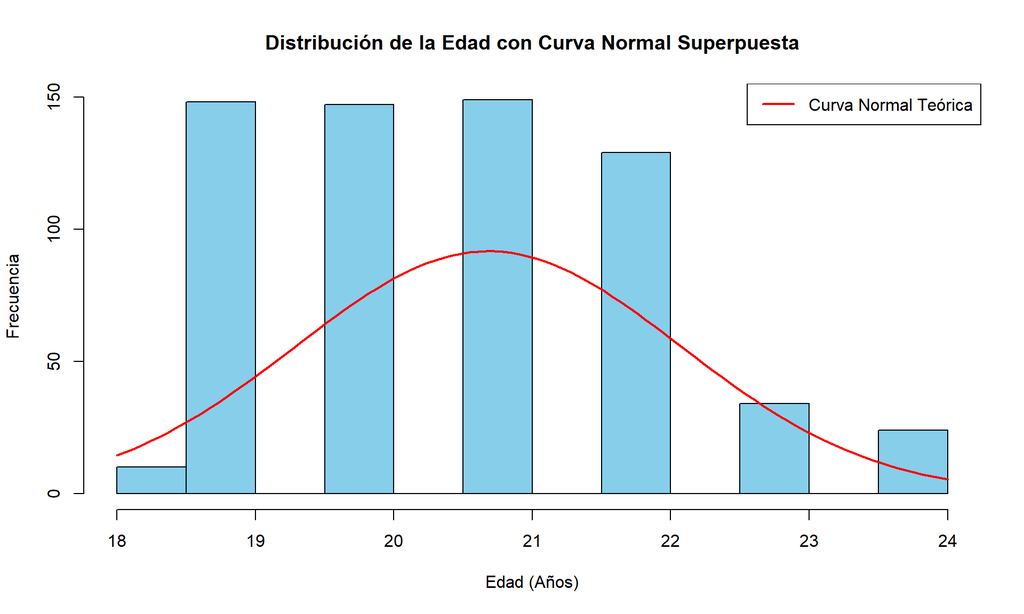

**Interpretación:**

Visualmente, el histograma de la edad muestra una forma que se asemeja a una campana, pero la curva normal superpuesta revela que las colas de la distribución de `Edad` son más cortas y el pico es más pronunciado de lo que se esperaría en una distribución normal perfecta.

##### **b) Gráfico Cuantil-Cuantil (Q-Q Plot)**

Un Q-Q plot compara los cuantiles de tus datos con los cuantiles teóricos de una distribución normal. Si los puntos caen cerca de la línea diagonal, los datos se distribuyen normalmente.

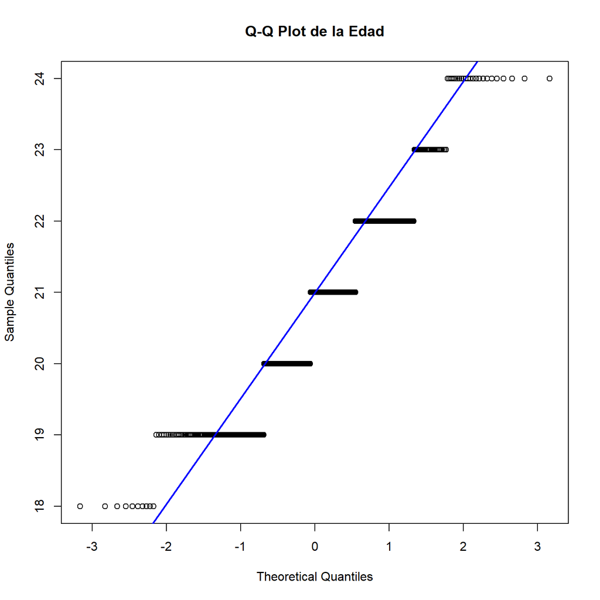

**Interpretación:**

En el Q-Q plot, observamos que los puntos se desvían de la línea recta en los extremos superior e inferior. Esta desviación indica que la distribución de la edad no sigue perfectamente una distribución normal. Las desviaciones en las colas sugieren que hay menos valores extremos de lo que una distribución normal predeciría (lo que se alinea con una curtosis negativa).

#### **Conclusión del Análisis de Normalidad**

Basado en las pruebas estadísticas (Shapiro-Wilk y Lilliefors) y las visualizaciones (histograma y Q-Q plot), se puede concluir que la variable `Edad` en este conjunto de datos **no sigue una distribución normal**. Las pruebas estadísticas arrojaron p-valores extremadamente bajos, lo que lleva al rechazo de la hipótesis de normalidad. Las visualizaciones confirman que, aunque la distribución tiene una forma algo parecida a una campana, no se ajusta a los supuestos de una distribución normal perfecta, especialmente en las colas.

## **2. Análisis de la Variable ‘Gender’**

Este análisis explorará la distribución y características de la variable `Gender` (Género). Dado que `Gender` es una variable cualitativa nominal, el análisis se centrará en las frecuencias y proporciones.

### **Frecuencias Absolutas y Relativas**

```
## --- Resumen de la Variable Gender ---
```

```
## female   male
##    317    324
```

```
## Frecuencias Absolutas:
```

```
## gender_data
## female   male
##    317    324
```

```
## Frecuencias Relativas (Proporciones):
```

```
## gender_data
## female   male
## 0.4945 0.5055
```

```
## Número total de encuestados: 641
```

**Interpretación:**

De un total de 641 encuestados, 317 se identifican como ‘female’ (femenino) y 324 como ‘male’ (masculino). Esto representa aproximadamente el 49.454% de la muestra para ‘female’ y el 50.546% para ‘male’. No se encontraron otras categorías de género en los datos después de la limpieza. Esto indica una ligera mayoría de encuestados masculinos en la muestra.

### **Visualización: Gráfico de Barras (Bar Plot) de Género**

Un gráfico de barras es la visualización más adecuada para variables cualitativas, ya que muestra la frecuencia o proporción de cada categoría.

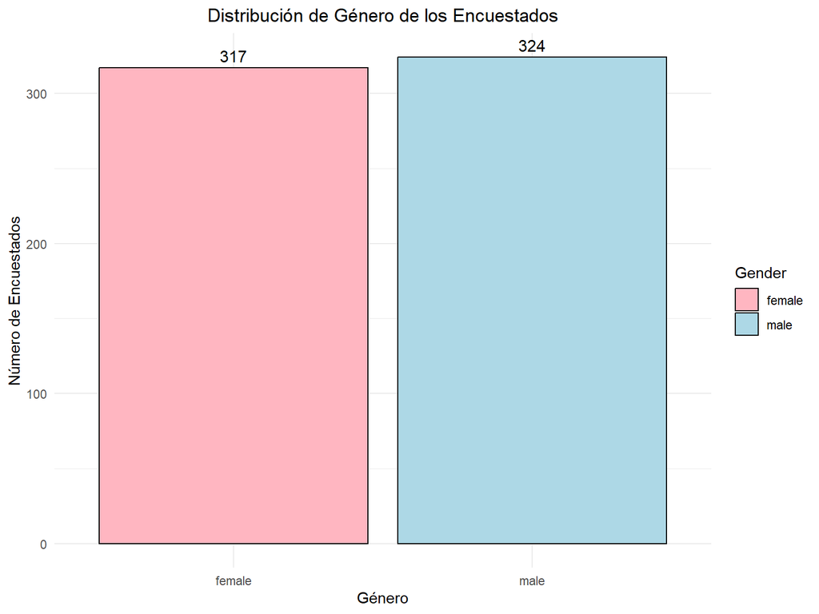

**Interpretación de la Visualización:**

El gráfico de barras confirma visualmente que hay más encuestados masculinos que femeninos en la muestra. Esta visualización es clara y concisa para una variable nominal como el género.

### **Conclusión del Análisis de Género**

La variable `Gender` es una variable cualitativa nominal que muestra una distribución de 49.454% de encuestados femeninos y 50.546% de encuestados masculinos. Esta información es fundamental para comprender la composición demográfica de la muestra y puede ser relevante al analizar cómo otras variables (como el uso de redes sociales o la salud mental) pueden diferir entre los géneros. Al ser una variable nominal, no se asocia a una distribución de probabilidad específica en el contexto de análisis de variables aleatorias continuas o discretas como las vistas anteriormente.

## **3. Análisis de la Variable ‘Academic_Level’**

Este análisis explorará la distribución y características de la variable `Academic_Level` (Nivel Académico). Como se identificó previamente, esta es una variable cualitativa ordinal, por lo que el análisis se centrará en las frecuencias y proporciones de cada categoría ordenada.

### **Frecuencias Absolutas y Relativas**

```
## --- Resumen de la Variable Academic_Level ---
```

```
##     ed. media universitario      titulado
##            22           318           301
```

```
## Frecuencias Absolutas:
```

```
## academic_level_data
##     ed. media universitario      titulado
##            22           318           301
```

```
## Frecuencias Relativas (Proporciones):
```

```
## academic_level_data
##     ed. media universitario      titulado
##       0.03432       0.49610       0.46958
```

```
## Número total de encuestados: 641
```

**Interpretación:**

De un total de 641 encuestados:

- 22 (3.4321%) están en el nivel de ‘ed. media’ (educación media).
- 318 (49.61%) están en el nivel de ‘universitario’ (pregrado).
- 301 (46.9579%) están en el nivel de ‘titulado’ (posgrado).

Esto indica que la muestra está distribuida con una ligera mayoría en el nivel de pregrado y una minoría en el nivel de educación media.

### **Visualización: Gráfico de Barras de Nivel Académico**

Un gráfico de barras es la visualización más adecuada para variables cualitativas, especialmente cuando son ordinales, ya que permite mostrar la distribución de las categorías en su orden inherente.

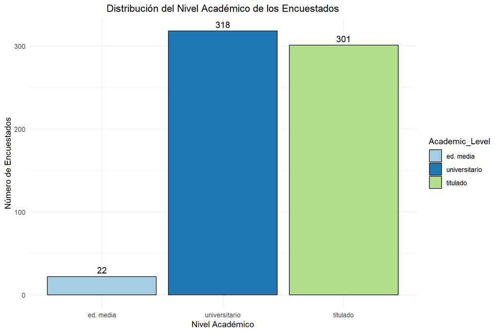

**Interpretación de la Visualización:**

El gráfico de barras confirma visualmente las proporciones calculadas, mostrando la cantidad de encuestados en cada nivel académico en el orden correcto. Se puede apreciar que los niveles de pregrado y posgrado tienen una mayor representación en esta muestra.

## **4. Análisis de la Variable ‘Avg_Daily_Usage_Hours’**

Este análisis explorará la distribución y características de la variable `Avg_Daily_Usage_Hours` (Horas promedio de uso diario). Esta es una variable cuantitativa continua, y se analizará mediante estadísticas descriptivas, visualizaciones y pruebas de normalidad.

### **Obtención de Estadísticas Descriptivas**

```
## --- Estadísticas Descriptivas para Avg_Daily_Usage_Hours ---
```

```
##    Min. 1st Qu.  Median    Mean 3rd Qu.    Max.
##    1.50    4.10    4.80    4.96    5.90    8.50
```

```
## Media (mean): 4.9616
```

```
## Desviación Estándar (sd): 1.2839
```

```
## Mediana: 4.8
```

```
## Tamaño de la muestra (N): 641
```

**Interpretación:**

Los encuestados pasan un promedio de aproximadamente 4.9616 horas al día en redes sociales, con la mitad de los encuestados utilizando 4.8 horas o menos. Los datos varían desde un mínimo de 1.5 horas hasta un máximo de 8.5 horas. Esto muestra que hay usuarios con un uso relativamente bajo y otros con un uso bastante elevado. El 50% central de los datos (entre el primer y el tercer cuartil) se encuentra entre 4.1 y 5.9 horas diarias. En cuanto a la dispersión de los datos, la desviación estándar de 1.2839 horas es relativamente baja en comparación con la media. Esto indica que la mayoría de los datos se agrupan de manera más estrecha alrededor de la media. El 50% central de los usuarios (entre el primer y el tercer cuartil) dedican entre 4.1 y 5.9 horas al día a las redes sociales, lo que refuerza la idea de una concentración de usuarios en ese rango.

### Visualización: Histograma de Horas de Uso Diario

Un histograma ayuda a visualizar la distribución de la variable `Avg_Daily_Usage_Hours`.

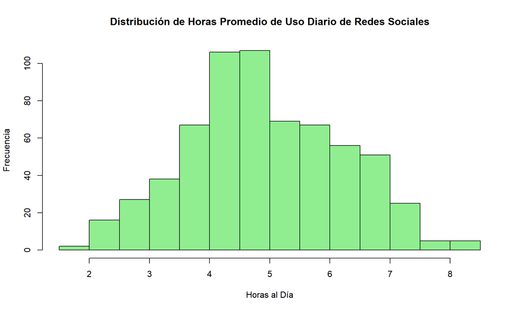

### Visualización: Diagrama de Caja (Box Plot) de Horas de Uso Diario

Un diagrama de caja es útil para identificar la dispersión de los datos y posibles valores atípicos (outliers).

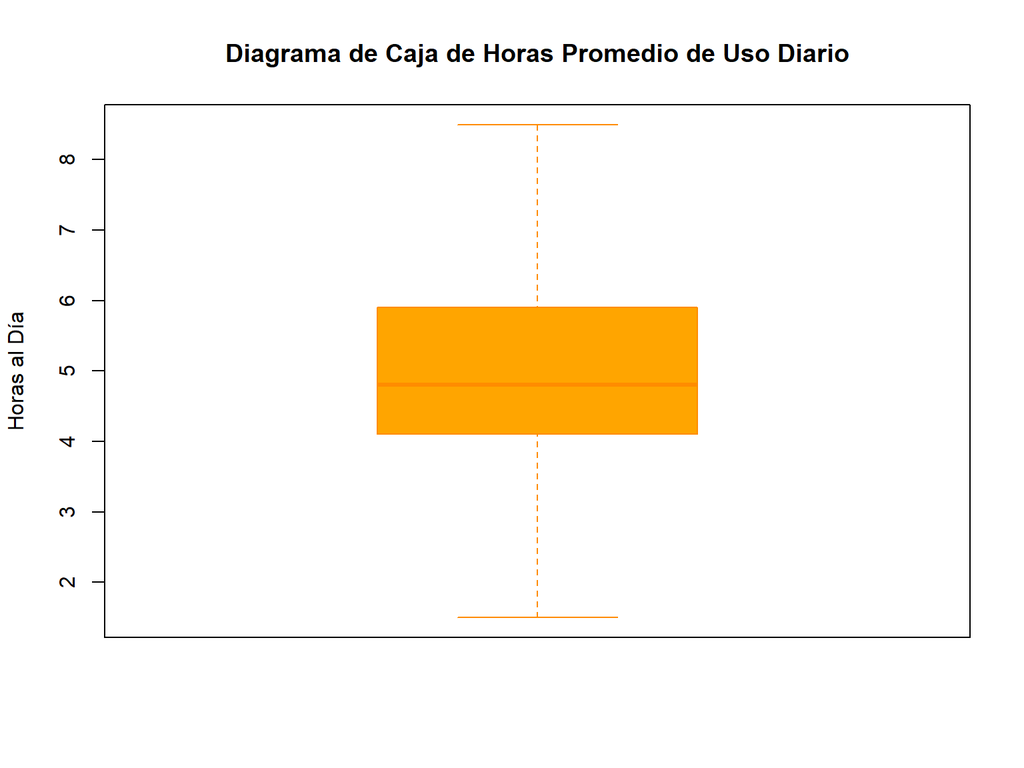

**Interpretación de las Visualizaciones:**

El **histograma** muestra una distribución que se concentra en el centro, con un pico alrededor de las 5 horas. El **diagrama de caja** no muestra valores atípicos extremos, confirmando que la mayoría de los datos están dentro del rango esperado de uso diario. La mediana está relativamente ubicada en el centro de la caja, lo que sugiere una distribución relativamente simétrica alrededor de ese punto para el 50% central.

### **Pruebas de Normalidad**

Se realizarán pruebas estadísticas para evaluar la hipótesis nula de que los datos provienen de una distribución normal.

#### **a) Prueba de Shapiro-Wilk**

Esta prueba es adecuada para tamaños de muestra pequeños a moderados (generalmente N < 5000).

- **Hipótesis Nula ($H\_0$):** Los datos se distribuyen normalmente.
- **Hipótesis Alternativa ($H\_1$):** Los datos no se distribuyen normalmente.

```
## --- Prueba de Shapiro-Wilk para Avg_Daily_Usage_Hours ---
```

```
##
##  Shapiro-Wilk normality test
##
## data:  usage_hours_data
## W = 0.99, p-value = 0.001
```

**Interpretación:** Dado que el p-valor es mucho menor que el nivel de significancia común (e.g., alpha = 0.05), **se rechaza la hipótesis nula**. Esto sugiere que la variable `Avg_Daily_Usage_Hours` **no sigue una distribución normal** según la prueba de Shapiro-Wilk.

#### **b) Prueba de Kolmogorov-Smirnov (Lilliefors)**

Esta prueba es una alternativa para tamaños de muestra más grandes.

- **Hipótesis Nula ($H\_0$):** Los datos se distribuyen normalmente.
- **Hipótesis Alternativa ($H\_1$):** Los datos no se distribuyen normalmente.

```
##
## --- Prueba de Lilliefors (Kolmogorov-Smirnov) para Avg_Daily_Usage_Hours ---
```

```
##
##  Lilliefors (Kolmogorov-Smirnov) normality test
##
## data:  usage_hours_data
## D = 0.07, p-value = 8e-08
```

**Interpretación:** Similar a la prueba de Shapiro-Wilk, el p-valor es significativamente menor que alpha = 0.05. Por lo tanto, **rechazamos la hipótesis nula**, lo que refuerza la conclusión de que la variable `Avg_Daily_Usage_Hours` **no se distribuye normalmente**.

### **Visualización de la Normalidad**

Las visualizaciones sirven para complementar las pruebas estadísticas y obtener una comprensión de la forma de la distribución.

#### **a) Histograma con Curva de Densidad Normal**

Se superpone una curva de densidad normal teórica (con la media y desviación estándar de los datos) sobre el histograma de las horas de uso diario.

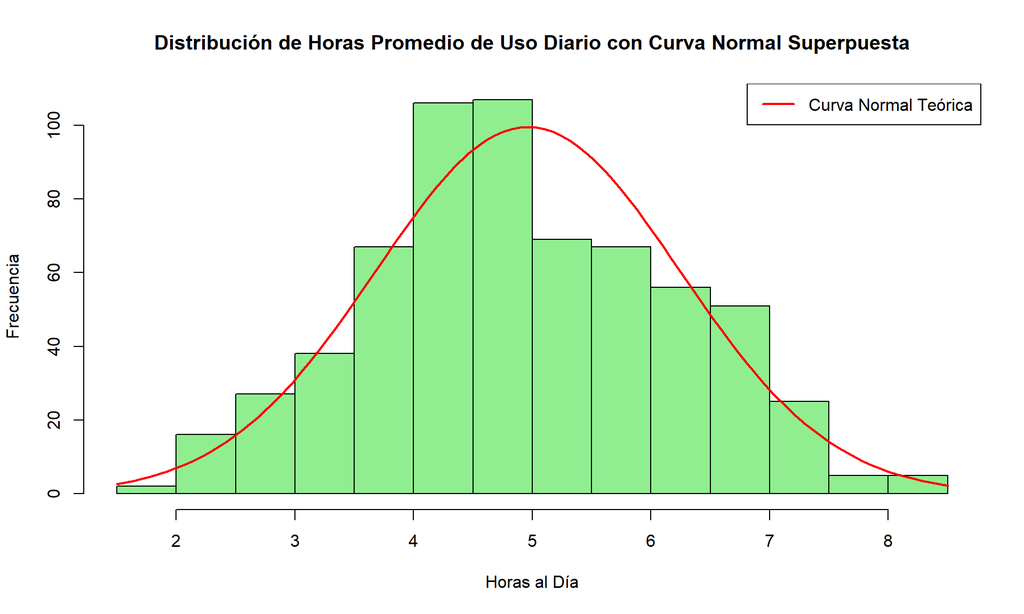

#### **b) Gráfico Cuantil-Cuantil (Q-Q Plot)**

Un Q-Q plot compara los cuantiles de los datos con los cuantiles teóricos de una distribución normal. Si los puntos caen cerca de la línea diagonal, los datos se distribuyen normalmente.

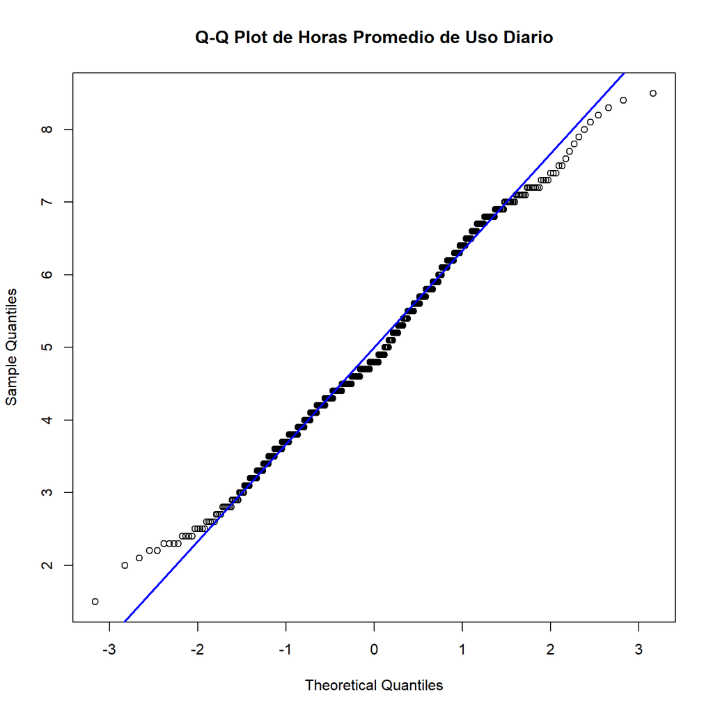

**Interpretación:**

El Q-Q plot muestra una desviación de la línea recta, especialmente en los extremos y en el centro. Esto es una indicación de que la variable `Avg_Daily_Usage_Hours` no sigue una distribución normal. Las desviaciones en los extremos sugieren que la distribución real tiene colas más pesadas o más ligeras de lo que una distribución normal predeciría.

### **Conclusión del Análisis de Normalidad para ‘Avg_Daily_Usage_Hours’**

Basado en las pruebas estadísticas (Shapiro-Wilk y Lilliefors) y las visualizaciones (histograma con curva normal y Q-Q plot), se puede concluir que la variable `Avg_Daily_Usage_Hours` **no sigue una distribución normal**. Las pruebas estadísticas arrojaron p-valores extremadamente bajos, lo que lleva al rechazo de la hipótesis de normalidad. Las visualizaciones confirman que la distribución tiene una forma irregular y desviaciones de la forma de campana esperada.

## **5. Análisis de la Variable ‘Affects_Academic_Performance’**

Este análisis explorará la distribución y características de la variable `Affects_Academic_Performance` (Afecta el Rendimiento Académico). Esta es una variable cualitativa nominal (booleana), por lo que se centrará en las frecuencias y proporciones de sus categorías.

### **Frecuencias Absolutas y Relativas**

```
## --- Resumen de la Variable Affects_Academic_Performance ---
```

```
##  no yes
## 220 421
```

```
## Frecuencias Absolutas:
```

```
## performance_data
##  no yes
## 220 421
```

```
## Frecuencias Relativas (Proporciones):
```

```
## performance_data
##     no    yes
## 0.3432 0.6568
```

```
## Número total de encuestados: 641
```

**Interpretación:** De un total de 641 encuestados:

- 220 (34.3214%) responden ‘no’, indicando que no consideran que el uso de redes sociales afecte negativamente su rendimiento académico.
- 421 (65.6786%) responden ‘yes’, indicando que sí consideran que el uso de redes sociales afecta negativamente su rendimiento académico.

Esto muestra que una mayoría significativa de los encuestados (casi dos tercios) percibe un impacto negativo de las redes sociales en su rendimiento académico.

### **Visualización: Gráfico de Barras de ‘Affects_Academic_Performance’**

Un gráfico de barras es la visualización más adecuada para variables cualitativas, mostrando la frecuencia o proporción de cada categoría.

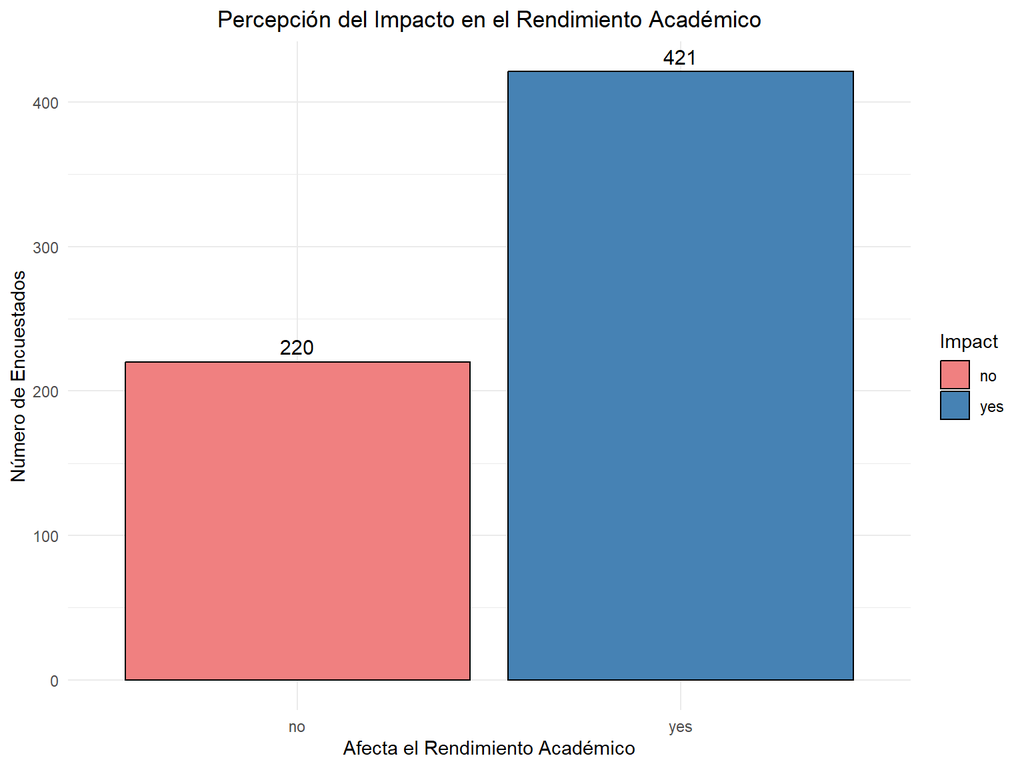

**Interpretación de la Visualización:**

El gráfico de barras confirma visualmente la predominancia de respuestas “Sí”, lo que subraya la percepción generalizada de un impacto negativo en el rendimiento académico entre los encuestados.

### **Distribución de Probabilidad Binomial**

Dado que `Affects_Academic_Performance` es una variable binaria (Sí/No), la distribución de probabilidad que naturalmente se asocia con el número de “éxitos” (por ejemplo, respuestas “Sí”) en una serie de ensayos independientes es la **Distribución Binomial**.

Para usar la distribución binomial, se necesita:

- **`size` (n):** El número de ensayos (en este caso, el número de encuestados en una sub-muestra o el total si se considera toda la población como ensayos).
- **`prob` (p):** La probabilidad de “éxito” (la proporción de respuestas “Sí” en la población o en la muestra grande).

Basado en nuestros datos, la probabilidad de que un encuestado responda “Sí” (nuestro ‘éxito’) es $p = 0.6568$.

**Ejemplo de Cálculo Binomial en R:**

Supongamos que se quiere saber la probabilidad de que, si se seleccionan 10 estudiantes al azar, **exactamente 7** de ellos consideren que el uso de redes sociales afecta negativamente su rendimiento académico.

```
## Probabilidad de que exactamente 7 de 10 estudiantes respondan 'Sí': 0.2558
```

**Interpretación del Ejemplo Binomial:** Este cálculo muestra la probabilidad puntual de obtener un número específico de “éxitos” en un número fijo de intentos, utilizando la probabilidad de éxito observada en el dataset.

### **Conclusión del Análisis de ‘Affects_Academic_Performance’**

La variable `Affects_Academic_Performance` es una variable cualitativa nominal que indica una clara percepción mayoritaria (65.6786%) de que el uso de redes sociales impacta negativamente el rendimiento académico entre los encuestados. Dada su naturaleza binaria, la **distribución Binomial** es la distribución de probabilidad adecuada para modelar el número de respuestas “Sí” o “No” en un conjunto de ensayos. Esta información sirve para entender el impacto percibido de las redes sociales y puede ser un punto de partida para análisis más profundos sobre las correlaciones con otras variables.

## **6. Análisis de la Variable ‘Sleep_Hours_Per_Night’**

Este análisis explorará la distribución y características de la variable `Sleep_Hours_Per_Night` (Horas de Sueño por Noche). Esta es una variable cuantitativa continua, y se analizará mediante estadísticas descriptivas, visualizaciones y pruebas de normalidad.

### **Obtención de Estadísticas Descriptivas**

```
## --- Estadísticas Descriptivas para Sleep_Hours_Per_Night ---
```

```
##    Min. 1st Qu.  Median    Mean 3rd Qu.    Max.
##    3.80    6.00    6.90    6.83    7.60    9.60
```

```
## Media (mean): 6.8334
```

```
## Desviación Estándar (sd): 1.1336
```

```
## Mediana: 6.9
```

```
## Tamaño de la muestra (N): 641
```

**Interpretación:**

Los encuestados duermen, en promedio, aproximadamente 6.8334 horas por noche, con una mediana de 6.9. La desviación estándar de 1.1336 horas indica una variabilidad moderada en las horas de sueño. Los datos varían desde un mínimo de 3.8 horas hasta un máximo de 9.6 horas. El 50% central de los datos (entre el primer y el tercer cuartil) se encuentra entre 6 y 7.6 horas por noche.

### **Visualización Descriptiva**

A continuación, se presentan un histograma y un diagrama de caja (box plot) para visualizar la distribución de las horas de sueño.

#### **a) Histograma de Horas de Sueño por Noche**

Este gráfico muestra la frecuencia de las horas de sueño, permitiendo observar la forma general de la distribución.

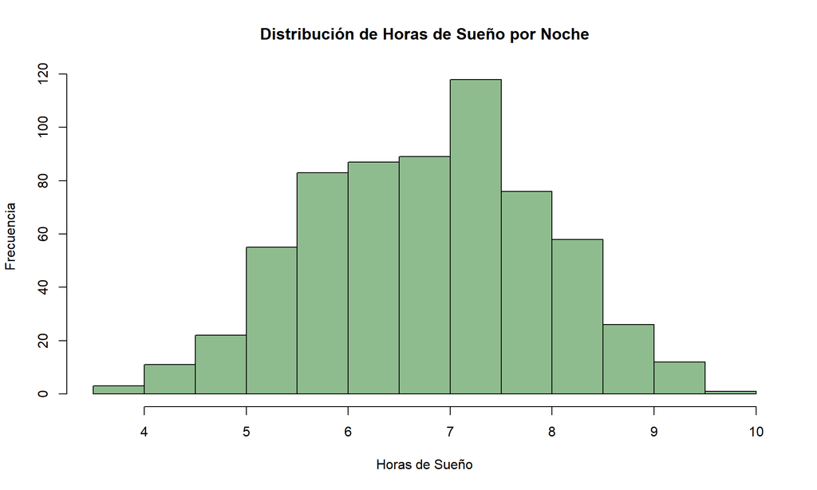

#### **b) Diagrama de Caja (Box Plot) de Horas de Sueño por Noche**

Este gráfico proporciona una vista de la dispersión de los datos y la presencia de posibles valores atípicos (outliers).

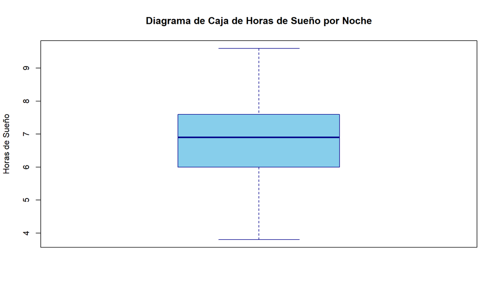

### **Pruebas de Normalidad**

Se realizarán pruebas estadísticas para evaluar la hipótesis nula de que los datos provienen de una distribución normal.

#### a) Prueba de Shapiro-Wilk

```
## --- Prueba de Shapiro-Wilk para Sleep_Hours_Per_Night ---
```

```
##
##  Shapiro-Wilk normality test
##
## data:  sleep_hours_data
## W = 0.99, p-value = 0.01
```

#### b) Prueba de Kolmogorov-Smirnov (Lilliefors)

```
##
## --- Prueba de Lilliefors (Kolmogorov-Smirnov) para Sleep_Hours_Per_Night ---
```

```
##
##  Lilliefors (Kolmogorov-Smirnov) normality test
##
## data:  sleep_hours_data
## D = 0.051, p-value = 4e-04
```

**Interpretación:**

De manera consistente, el p-valor es muy pequeño, llevando a **rechazar la hipótesis nula** de normalidad. Esta prueba también indica que la variable `Sleep_Hours_Per_Night` **no sigue una distribución normal**.

### Visualización de la Normalidad

Las visualizaciones son cruciales para complementar las pruebas estadísticas.

#### **a) Histograma con Curva de Densidad Normal**

Se superpone una curva de densidad normal teórica (con la media y desviación estándar de los datos) sobre el histograma de las horas de sueño.

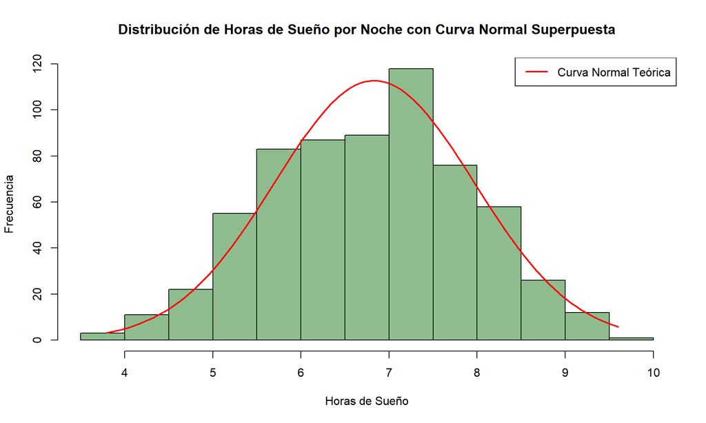

#### **b) Gráfico Cuantil-Cuantil (Q-Q Plot)**

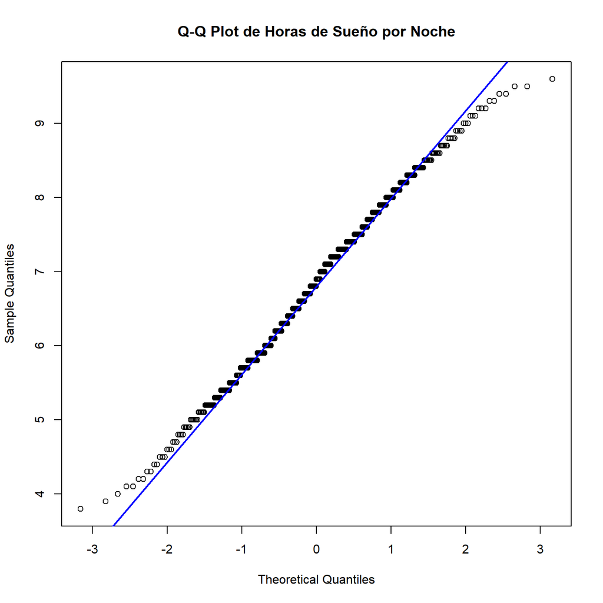

### **Conclusión del Análisis de Normalidad para ‘Sleep_Hours_Per_Night’**

La variable `Sleep_Hours_Per_Night` muestra que los encuestados duermen en promedio alrededor de 6.8334 horas por noche. Sin embargo, el análisis de normalidad concluye que **esta variable no sigue una distribución normal**.

## **7. Análisis de la Variable ‘Mental_Health_Score’**

Este análisis explorará la distribución y características de la variable `Mental_Health_Score` (Puntuación de Salud Mental). Esta es una variable cuantitativa discreta, y la analizaremos mediante estadísticas descriptivas, visualizaciones y pruebas de normalidad. También consideraremos la aplicabilidad de la distribución de Poisson, dado que es una puntuación de conteo.

### **Obtención de Estadísticas Descriptivas**

```
## --- Estadísticas Descriptivas para Mental_Health_Score ---
```

```
##    Min. 1st Qu.  Median    Mean 3rd Qu.    Max.
##    1.00    3.00    4.00    3.81    5.00    6.00
```

```
## Media (mean): 3.8081
```

```
## Desviación Estándar (sd): 1.1148
```

```
## Varianza: 1.2428
```

```
## Mediana: 4
```

```
## Tamaño de la muestra (N): 641
```

**Interpretación:**

Las puntuaciones de salud mental varían desde un mínimo de 1 hasta un máximo de 6. La media es de aproximadamente 3.8081 y la mediana es 4, lo que sugiere una distribución ligeramente sesgada o concentrada. La desviación estándar de 1.1148 indica una dispersión moderada de las puntuaciones. El 50% central de los encuestados reporta puntuaciones entre 3 y 5.

### **Visualización Descriptiva**

A continuación, se presentan un histograma y un diagrama de caja (box plot) para visualizar la distribución de las puntuaciones de salud mental.

#### **a) Histograma de Puntuación de Salud Mental**

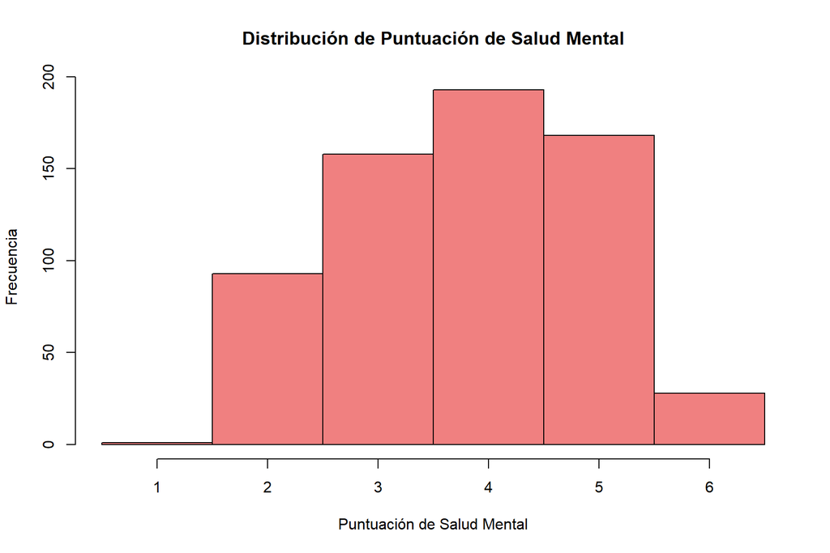

#### b) Diagrama de Caja (Box Plot) de Puntuación de Salud Mental

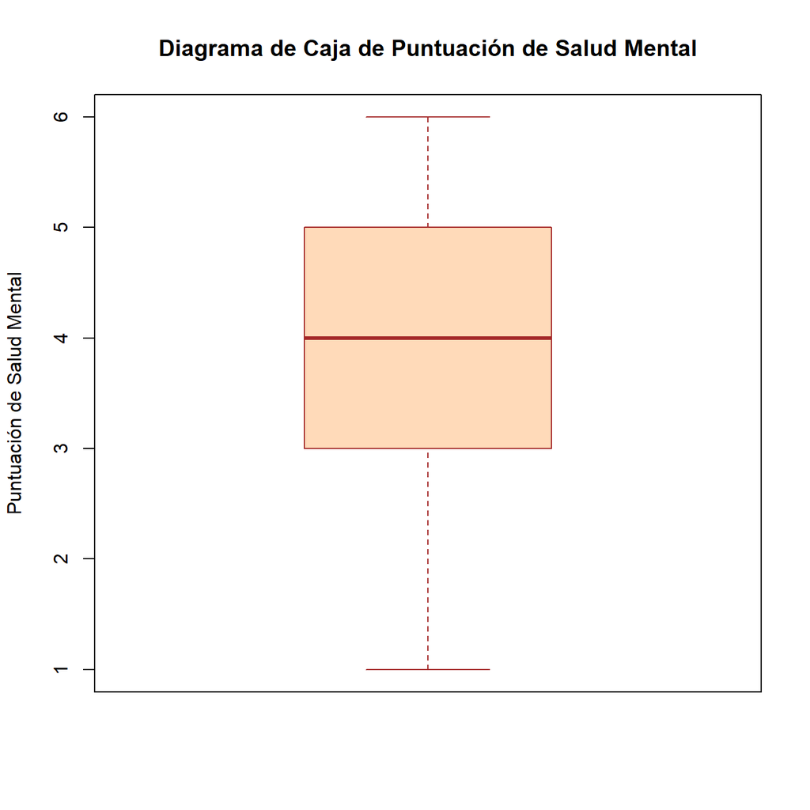

### **Consideración de la Distribución de Poisson**

La distribución de Poisson se utiliza para modelar el número de eventos en un intervalo de tiempo o espacio, o el número de ocurrencias de un evento en un conjunto fijo de observaciones, donde los eventos son raros y la media y la varianza son aproximadamente iguales.

- **Media ($\lambda$):** 3.8081
- **Varianza:** 1.2428

Dado que la **media (3.8081) y la varianza (1.2428) son diferentes**, la variable `Mental_Health_Score` no parece seguir una distribución de Poisson de manera estricta. Una varianza menor que la media (lo que ocurre aquí, 1.2428 < 3.8081) sugiere un fenómeno llamado “subdispersión”, lo cual es una desviación del modelo de Poisson.

### **Pruebas de Normalidad**

Aunque `Mental_Health_Score` es discreta, a menudo se comprueba su “normalidad” para ver si puede ser razonablemente aproximada por una distribución normal, especialmente si tiene un rango amplio y muchos valores.

#### **Prueba de Shapiro-Wilk**

```
## --- Prueba de Shapiro-Wilk para Mental_Health_Score ---
```

```
##
##  Shapiro-Wilk normality test
##
## data:  mental_health_data
## W = 0.91, p-value <2e-16
```

**Interpretación:**

El p-valor es extremadamente bajo (mucho menor que $\alpha = 0.05$). Esto nos lleva a **rechazar la hipótesis nula** de normalidad. Se sugiere que la variable `Mental_Health_Score` **no sigue una distribución normal**.

### **Visualización de la Normalidad**

Las visualizaciones son cruciales para complementar las pruebas estadísticas.

#### **a) Histograma con Curva de Densidad Normal Superpuesta**

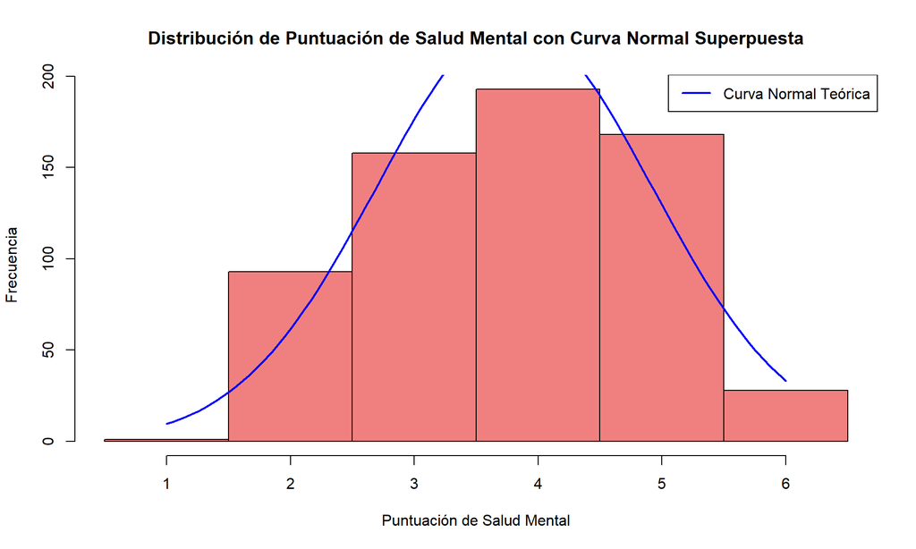

**Interpretación:**

#### **b) Gráfico Cuantil-Cuantil (Q-Q Plot)**

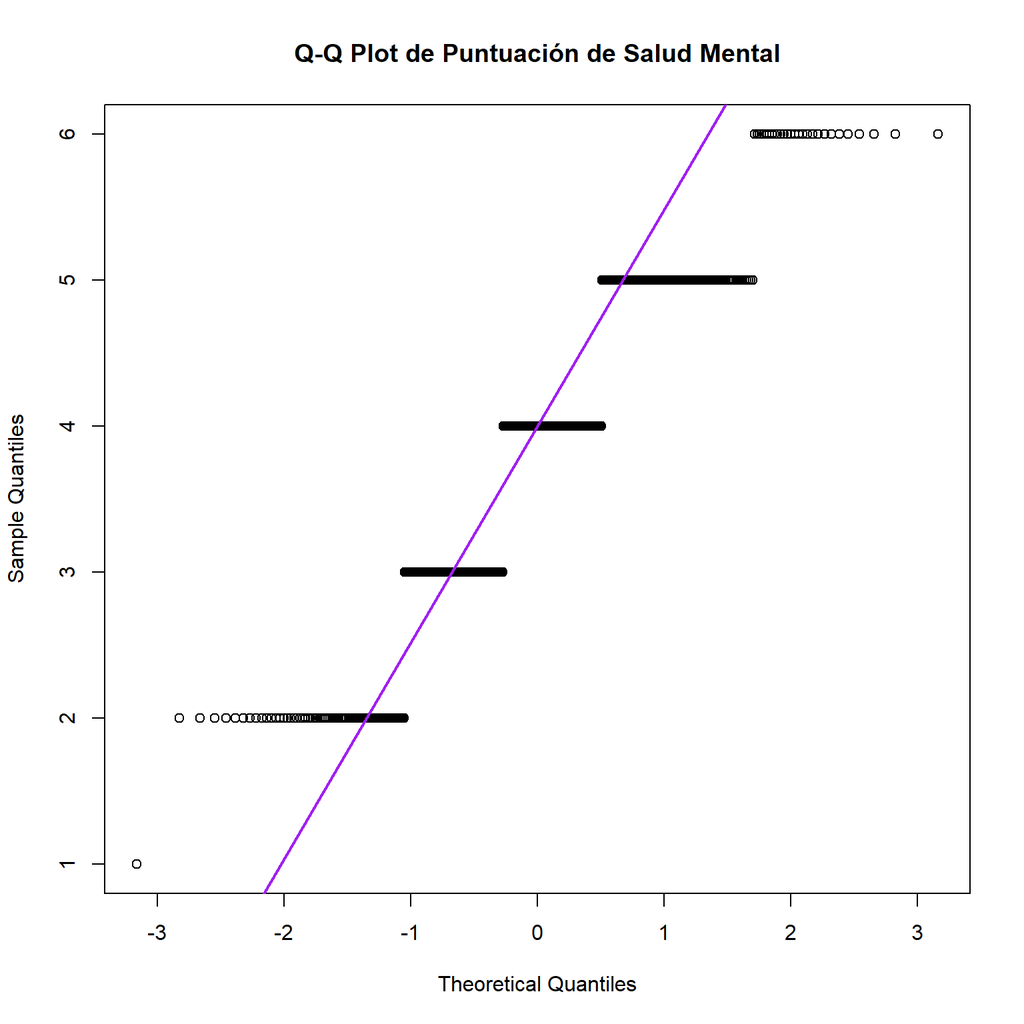

**Interpretación:**

El Q-Q plot de la variable `Mental_Health_Score` muestra una desviación muy clara y escalonada de la línea diagonal. Esta forma de “escalera” es característica de datos discretos que no se distribuyen normalmente. Los puntos no se alinean con la línea, lo que es una fuerte indicación de no normalidad.

### **Conclusión del Análisis Completo de ‘Mental_Health_Score’**

La variable `Mental_Health_Score` es una puntuación discreta que varía de 1 a 6, con una media de aproximadamente 3.8081.

## **8. Análisis de la Variable ‘Conflicts_Over_Social_Media’**

Este análisis explorará la distribución y características de la variable `Conflicts_Over_Social_Media` (Número de conflictos o discusiones relacionados con el uso de redes sociales). Esta es una variable cuantitativa discreta (de conteo), y la analizaremos mediante estadísticas descriptivas, visualizaciones y pruebas de normalidad. También consideraremos la aplicabilidad de la distribución de Poisson.

### **Obtención de Estadísticas Descriptivas**

```
## --- Estadísticas Descriptivas para Conflicts_Over_Social_Media ---
```

```
##    Min. 1st Qu.  Median    Mean 3rd Qu.    Max.
##     0.0     2.0     3.0     2.9     4.0     5.0
```

```
## Media (mean): 2.897
```

```
## Mínimo: 0
```

```
## Máximo: 5
```

```
## 1er Cuartil: 2
```

```
## 3er Cuartil: 4
```

```
## Desviación Estándar (sd): 0.953
```

```
## Varianza: 0.9081
```

```
## Mediana: 3
```

```
## Tamaño de la muestra (N): 641
```

**Interpretación:**

### **Visualización Descriptiva**

A continuación, se presentan un histograma y un diagrama de caja (box plot) para visualizar la distribución del número de conflictos.

#### **a) Histograma de Conflictos por Redes Sociales**

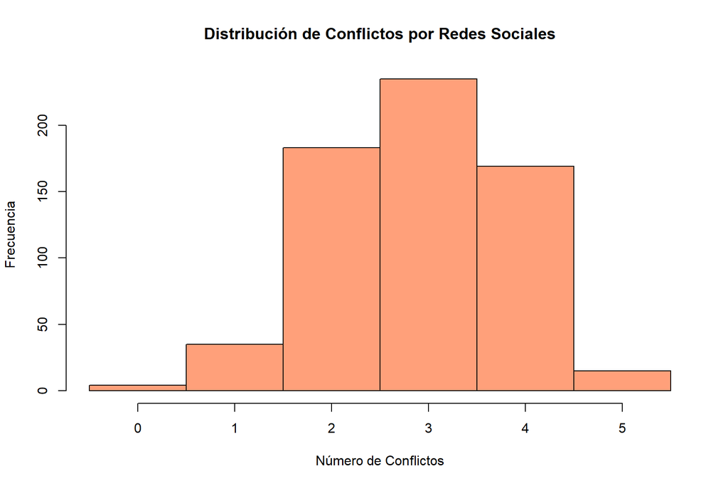

**Interpretación:**

#### b) Diagrama de Caja (Box Plot) de Conflictos por Redes Sociales

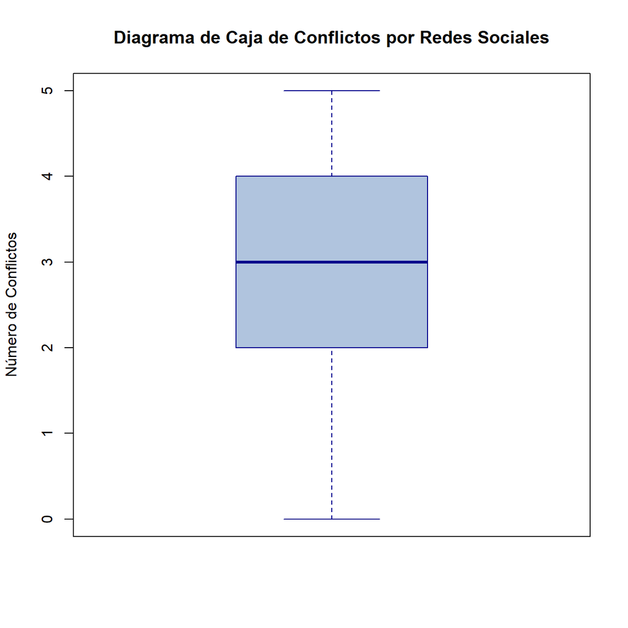

**Interpretación:**

### **Consideración de la Distribución de Poisson**

La distribución de Poisson se utiliza para modelar el número de eventos en un intervalo de tiempo o espacio, o el número de ocurrencias de un evento. Una característica clave de la distribución de Poisson es que su **media ($\lambda$) es igual a su varianza**.

- **Media ($\lambda$):** 2.897
- **Varianza:** 0.9081

Dado que la **media (2.897) y la varianza (0.9081) son diferentes**, la variable `Conflicts_Over_Social_Media` no parece seguir una distribución de Poisson. Una varianza menor que la media (lo que ocurre aquí, 0.9081 < 2.897) sugiere un fenómeno llamado “subdispersión”, lo cual es una desviación del modelo de Poisson.

### **Pruebas de Normalidad**

Aunque `Conflicts_Over_Social_Media` es discreta, se evalúa su “normalidad” para ver si puede ser aproximada por una distribución normal.

#### **a) Prueba de Shapiro-Wilk**

```
## --- Prueba de Shapiro-Wilk para Conflicts_Over_Social_Media ---
```

```
##
##  Shapiro-Wilk normality test
##
## data:  conflicts_data
## W = 0.9, p-value <2e-16
```

**Interpretación:** El p-valor es extremadamente bajo (mucho menor que $\alpha = 0.05$). Esto nos lleva a **rechazar la hipótesis nula** de normalidad. Se sugiere que la variable `Conflicts_Over_Social_Media` **no sigue una distribución normal**.

### **Visualización de la Normalidad**

Las visualizaciones son cruciales para complementar las pruebas estadísticas.

#### **a) Histograma con Curva de Densidad Normal Superpuesta**

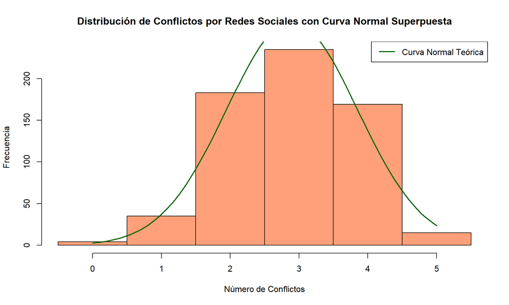

**Interpretación:**

#### b) Gráfico Cuantil-Cuantil (Q-Q Plot)

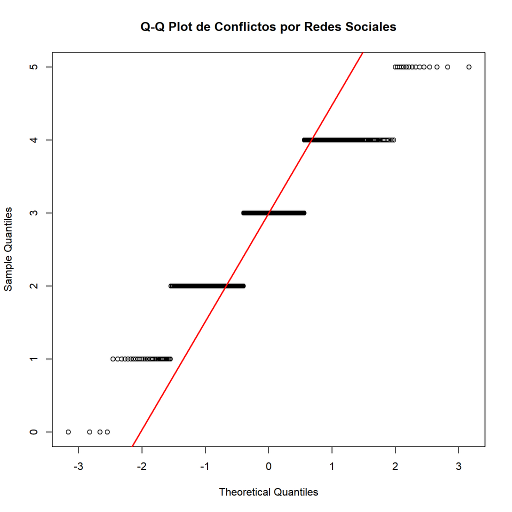

**Interpretación:**

El Q-Q plot de la variable `Conflicts_Over_Social_Media` muestra una desviación muy pronunciada y escalonada de la línea diagonal, lo que es una fuerte indicación de no normalidad. La forma de “escalera” es típica de datos discretos que no siguen una distribución normal.

### **Conclusión del Análisis Completo de ‘Conflicts_Over_Social_Media’**

La variable `Conflicts_Over_Social_Media` es una variable de conteo que indica el número de conflictos, con una media de aproximadamente 2.897.

## **9. Análisis de la Variable ‘Avg_Time_Between_Usage_Min’**

Este análisis explorará la distribución y características de la variable `Avg_Time_Between_Usage_Min` (Tiempo promedio entre usos de redes sociales en minutos). Esta es una variable cuantitativa continua (tiempo), y la analizaremos mediante estadísticas descriptivas, visualizaciones y pruebas de normalidad. También consideraremos la aplicabilidad de la distribución exponencial, dado que modela tiempos entre eventos.

### **Obtención de Estadísticas Descriptivas**

```
## --- Estadísticas Descriptivas para Avg_Time_Between_Usage_Min ---
```

```
##    Min. 1st Qu.  Median    Mean 3rd Qu.    Max.
##    20.0    40.0    60.0    69.6   100.0   180.0
```

```
## Media (mean): 69.61
```

```
## Desviación Estándar (sd): 31.4941
```

```
## Mediana: 60
```

```
## Tamaño de la muestra (N): 641
```

**Interpretación:**

El tiempo promedio que transcurre entre usos de redes sociales es de aproximadamente 69.61 minutos (poco más de una hora), con una mediana de 60 minutos. Hay una dispersión considerable en los datos, como lo indica la desviación estándar de 31.4941 minutos. Los tiempos varían desde un mínimo de 20 minutos hasta un máximo de 180 minutos (3 horas). El 50% central de los encuestados reporta tiempos entre 40 y 100 minutos.

### **Visualización Descriptiva**

A continuación, se presentan un histograma y un diagrama de caja (box plot) para visualizar la distribución del tiempo entre usos.

#### **a) Histograma de Tiempo Promedio entre Usos**

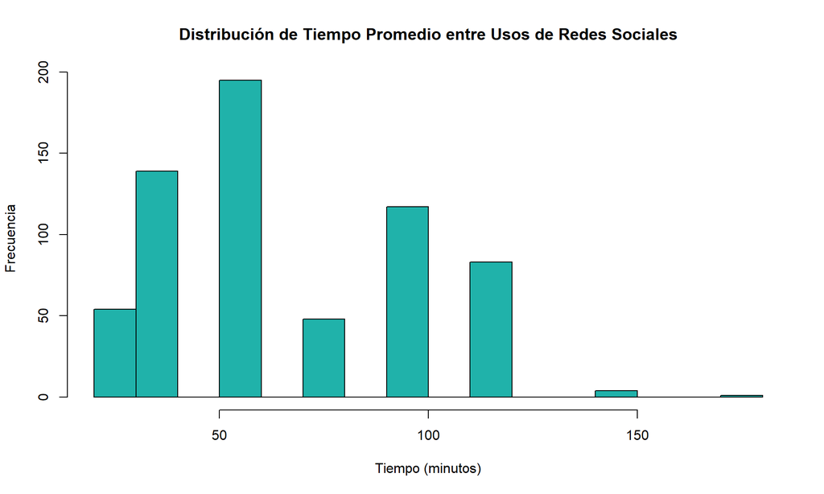

**Interpretación:**

El histograma muestra que la mayoría de los encuestados reportan tiempos más cortos entre usos (concentración en los valores inferiores) y una cola larga hacia la derecha, indicando que hay menos encuestados con tiempos muy largos entre usos. La distribución está claramente sesgada a la derecha.

#### **b) Diagrama de Caja (Box Plot) de Tiempo Promedio entre Usos**

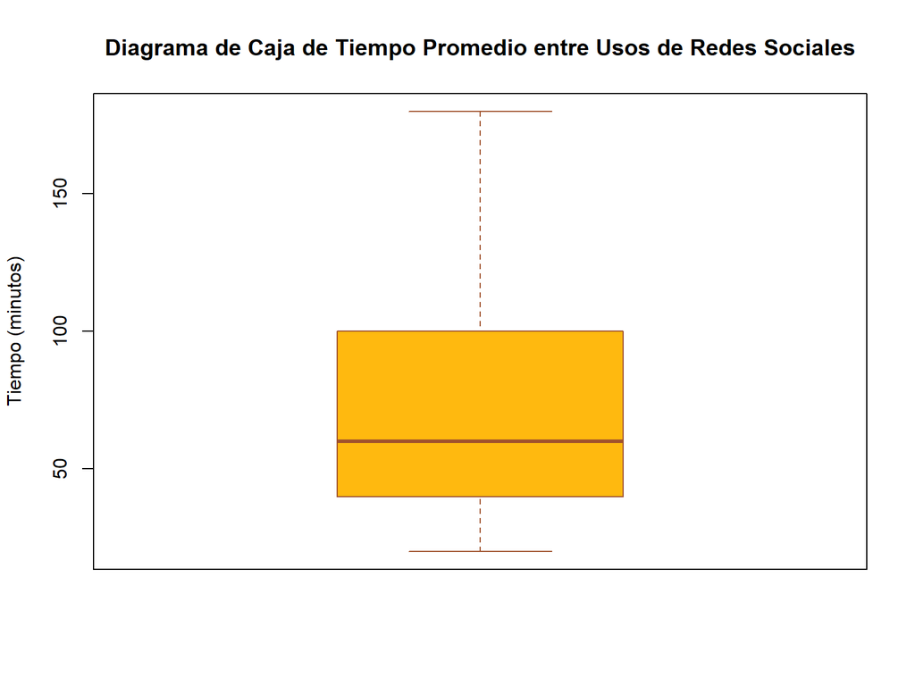

**Interpretación:**

### **Consideración de la Distribución Exponencial**

La distribución exponencial es comúnmente utilizada para modelar el tiempo hasta que ocurre un evento, o el tiempo entre eventos en un proceso de Poisson. Se caracteriza por su parámetro de **tasa ($\lambda$)**, donde la media de la distribución es $1/\lambda$.

La desviación estándar de una distribución exponencial es también $1/\lambda$, es decir, igual a la media. En nuestros datos, la media (69.61) es bastante diferente de la desviación estándar (31.4941), lo que sugiere que una distribución exponencial estricta podría no ser el mejor ajuste, aunque la forma general del histograma (sesgada a la derecha) es consistente con ella.

#### **Superposición de Curva de Densidad Exponencial:**

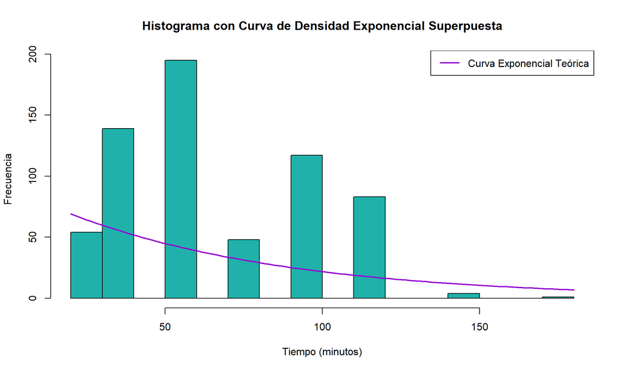

**Interpretación de la Superposición:**

### **Pruebas de Normalidad**

Aunque la hipótesis principal es la Exponencial, evaluamos la “normalidad” para descartarla o confirmar su no aplicabilidad.

#### **a) Prueba de Shapiro-Wilk**

```
## --- Prueba de Shapiro-Wilk para Avg_Time_Between_Usage_Min ---
```

```
##
##  Shapiro-Wilk normality test
##
## data:  time_between_usage_data
## W = 0.91, p-value <2e-16
```

**Interpretación:**

El p-valor es extremadamente bajo (mucho menor que $\alpha = 0.05$). Esto nos lleva a **rechazar la hipótesis nula** de normalidad. Se sugiere que la variable `Avg_Time_Between_Usage_Min` **no sigue una distribución normal**.

### **Visualización de la Normalidad**

Las visualizaciones son cruciales para complementar las pruebas estadísticas.

#### **a) Histograma con Curva de Densidad Normal Superpuesta**

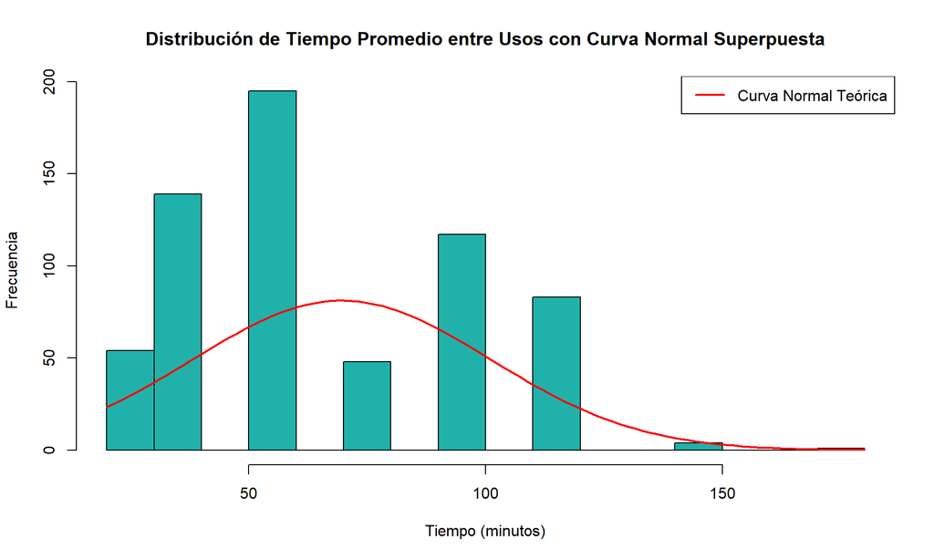

**Interpretación:**

El histograma con la curva normal superpuesta muestra que la distribución de `Avg_Time_Between_Usage_Min` está fuertemente sesgada a la derecha y no se parece en absoluto a una distribución normal. La curva normal es simétrica y no captura la forma de los datos.

#### **b) Gráfico Cuantil-Cuantil (Q-Q Plot)**

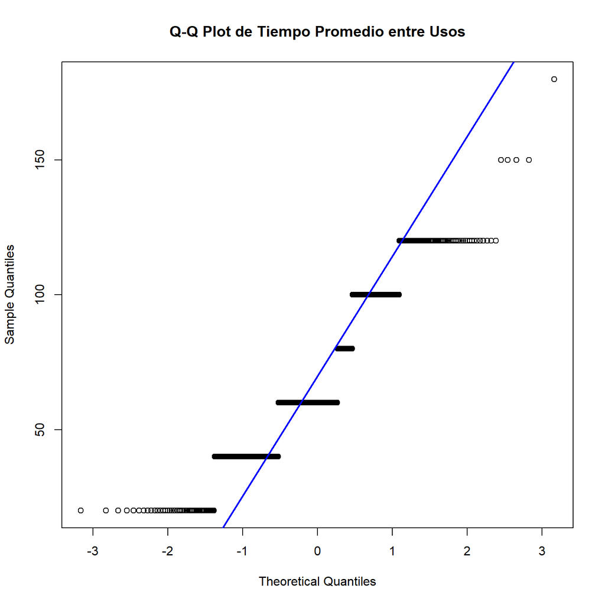

**Interpretación:**

### **Conclusión del Análisis Completo de ‘Avg_Time_Between_Usage_Min’**

La variable `Avg_Time_Between_Usage_Min` representa el tiempo promedio entre usos de redes sociales, con una media de 69.61 minutos y una fuerte concentración en valores más bajos.

- **Distribución Exponencial:** Aunque el histograma muestra una forma sesgada a la derecha consistente con una distribución exponencial, la **desviación estándar (31.4941) no es igual a la media (69.61)**, lo que sugiere que los datos no se ajustan perfectamente a un modelo exponencial puro. Podría ser una distribución exponencial modificada o una combinación de factores.
- **Normalidad:** Las pruebas estadísticas (Shapiro-Wilk) y las visualizaciones (histograma con curva normal y Q-Q plot) concluyen de manera consistente que **esta variable no sigue una distribución normal**.

Por lo tanto, para análisis inferenciales que involucren `Avg_Time_Between_Usage_Min`, se debe tener precaución. Aunque la distribución exponencial es una hipótesis razonable por la naturaleza de la variable (tiempo entre eventos), su ajuste perfecto no está confirmado.

## **10. Análisis de la Variable ‘Most_Used_Platform’**

Este análisis explorará la distribución y características de la variable `Most_Used_Platform` (Plataforma de Red Social Más Usada). Esta es una variable cualitativa nominal, por lo que nos centraremos en las frecuencias y proporciones de sus categorías.

### **Frecuencias y Proporciones de ‘Most_Used_Platform’**

```
## --- Resumen de la Variable Most_Used_Platform ---
```

```
##  facebook instagram  linkedin    tiktok   twitter  whatsapp   youtube
##       123       249        21       154        30        54        10
```

```
## Frecuencias Absolutas:
```

```
## platform_data
##  facebook instagram  linkedin    tiktok   twitter  whatsapp   youtube
##       123       249        21       154        30        54        10
```

```
## Frecuencias Relativas (Proporciones):
```

```
## platform_data
##  facebook instagram  linkedin    tiktok   twitter  whatsapp   youtube
##   0.19189   0.38846   0.03276   0.24025   0.04680   0.08424   0.01560
```

```
## Número total de encuestados: 641
```

**Interpretación:**

Estos resultados indican que Instagram y TikTok son las plataformas dominantes entre los encuestados, seguidas de Facebook y WhatsApp.

### **Visualización: Gráfico de Barras de ‘Most_Used_Platform’**

Un gráfico de barras es la visualización más adecuada para variables cualitativas, mostrando la frecuencia o proporción de cada categoría. Se ordenarán las barras por frecuencia de forma descendente para facilitar la interpretación.

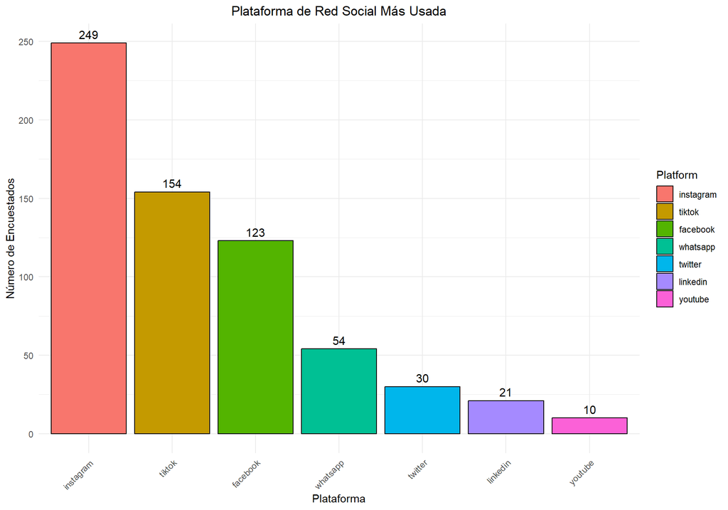

**Interpretación de la Visualización:**

El gráfico de barras confirma visualmente que Instagram y TikTok son las plataformas más utilizadas, seguidas por Facebook y WhatsApp. La representación visual facilita la comparación directa de la popularidad de cada plataforma.

### **Conclusión del Análisis de ‘Most_Used_Platform’**

La variable `Most_Used_Platform` es una variable cualitativa nominal que describe la preferencia de los encuestados por una plataforma de red social principal. El análisis revela que **Instagram y TikTok son las plataformas dominantes**, seguidas por Facebook y WhatsApp. Dada la naturaleza cualitativa nominal de la variable, no se asocia con una distribución de probabilidad paramétrica como Binomial, Poisson, Normal o Exponencial. El análisis descriptivo mediante tablas de frecuencia y gráficos de barras es el método más apropiado para entender su distribución. Esta información es valiosa para comprender el panorama de uso de redes sociales entre la población estudiada.

## **11. Análisis de la Variable ‘How_Many_Platforms’**

Este análisis explorará la distribución y características de la variable `How_Many_Platforms` (Cuántas plataformas de redes sociales utiliza activamente). Esta es una variable cuantitativa discreta (de conteo), y se analizará mediante estadísticas descriptivas, visualizaciones y pruebas de normalidad. También se considerará la aplicabilidad de la distribución de Poisson.

### **Obtención de Estadísticas Descriptivas**

```
## --- Estadísticas Descriptivas para How_Many_Platforms ---
```

```
##    Min. 1st Qu.  Median    Mean 3rd Qu.    Max.
##    1.00    4.00    5.00    4.31    5.00    5.00
```

```
## Media (mean): 4.3058
```

```
## Desviación Estándar (sd): 1.1153
```

```
## Varianza: 1.2439
```

```
## Mediana: 5
```

```
## Tamaño de la muestra (N): 641
```

**Interpretación:**

Los encuestados utilizan, en promedio, aproximadamente 4.3058 plataformas de redes sociales, con una mediana de 5 plataformas. La desviación estándar de 1.1153 plataformas indica una dispersión moderada en el número de plataformas utilizadas. Los datos varían desde un mínimo de 1 plataforma hasta un máximo de 5 plataformas. El 50% central de los encuestados utiliza entre 4 y 5 plataformas.

### **Visualización Descriptiva**

A continuación, se presentan un histograma y un diagrama de caja (box plot) para visualizar la distribución del número de plataformas.

#### **a) Histograma de Cuántas Plataformas**

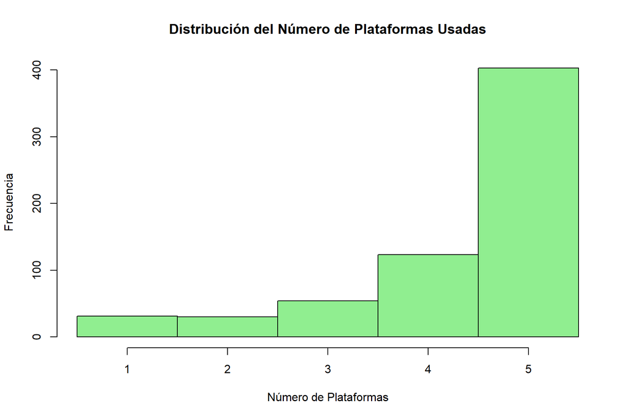

**Interpretación:**

#### **b) Diagrama de Caja (Box Plot) de Cuántas Plataformas**

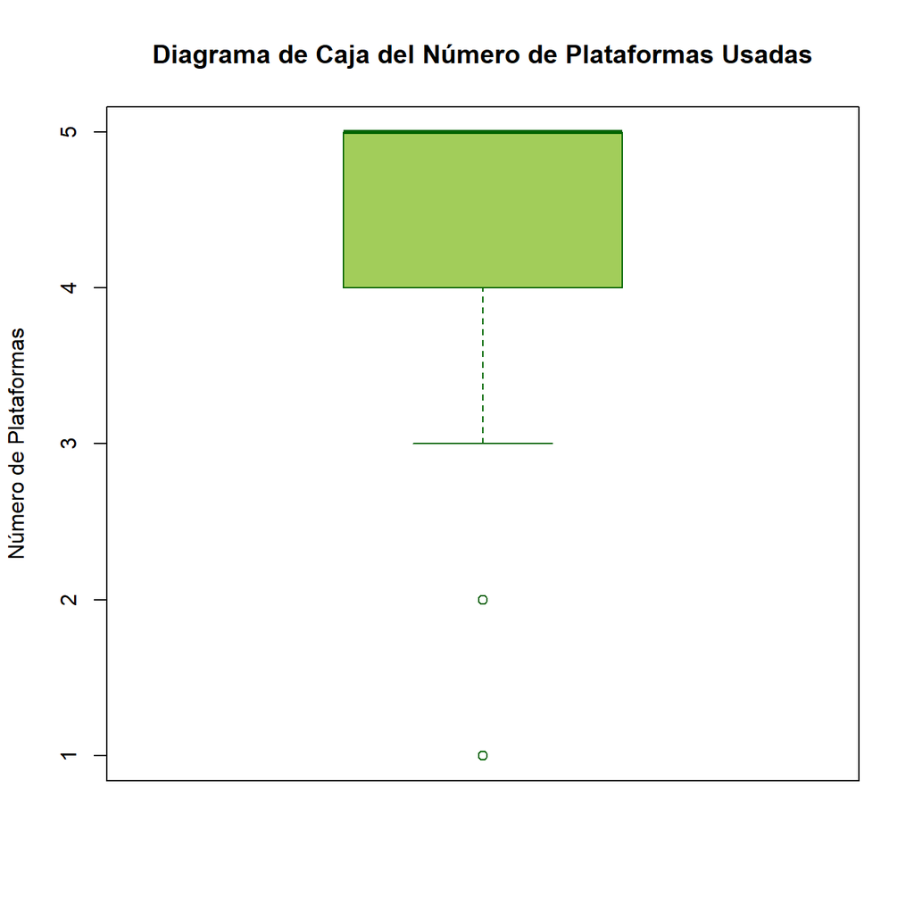

**Interpretación:**

### **Consideración de la Distribución de Poisson**

La distribución de Poisson modela el número de eventos en un intervalo, donde la media ($\lambda$) es igual a la varianza.

- **Media ($\lambda$):** 4.3058
- **Varianza:** 1.2439

En este caso, la **media (4.3058) y la varianza (1.2439) son diferentes**. La varianza es significativamente menor que la media, lo que indica **subdispersión**. Por lo tanto, la distribución de Poisson **no es un modelo adecuado** para la variable `How_Many_Platforms`.